# FIM-noisy-GRW

This repository contains the code related to the article *Observed Fisher Information in hidden Markov models - Application to a noisy Gaussian random walk* (Alexandra Lefebvre and Grégory Nuel, 2026) for the exact computation of the score and the observed Fisher information matrix (observed FIM) of the log-likelihood of a Gaussian random walk observed through Gaussian noise. Main functions are contained in the directory *R_code* along with detailed inputs and outputs. We provide below a brief overview of main uses of these functions.

# Notation

We consider a Gaussian random walk (GRW) observed through Gaussian noise composed of a latent Markov chain $X = (X_1,\ldots,X_n)$ and observed variables $Z = (Z_1,\ldots,Z_n)$ such that $X_1$ is univariate Gaussian of mean $\alpha$ and variance $\varepsilon^2$, for $i\in\{2,\ldots,n\}$
$$X_i = X_{i-1} + \varepsilon U_{i-1},$$
and for $i\in\{1,\ldots,n\}$
$$Z_i = X_i + \eta V_{i}$$
where and $\{U_i\}_{i\in\{1,\ldots,n-1\}}$, $\{V_i\}_{i\in\{1,\ldots,n\}}$ are independent and identically distributed standard Gaussian variables. The joint distribution of $X$ and $Z$ writes

$$P(X,Z=z|\theta) =
g(X_1,\alpha, \varepsilon), \prod_{i=2}^n g(X_i,X_{i-1},\varepsilon)
\prod_{i=1}^n g(z_i,X_i,\eta)$$
where $g(., \mu, \sigma)$ denotes the Gaussian density of mean $\mu$ and standard deviation $\sigma$.

# Dataset simulation

The function *simu* contained in the file *simulation.R* can be used for simulating a dataset as a list of observed sequences generated by a latent GRW.

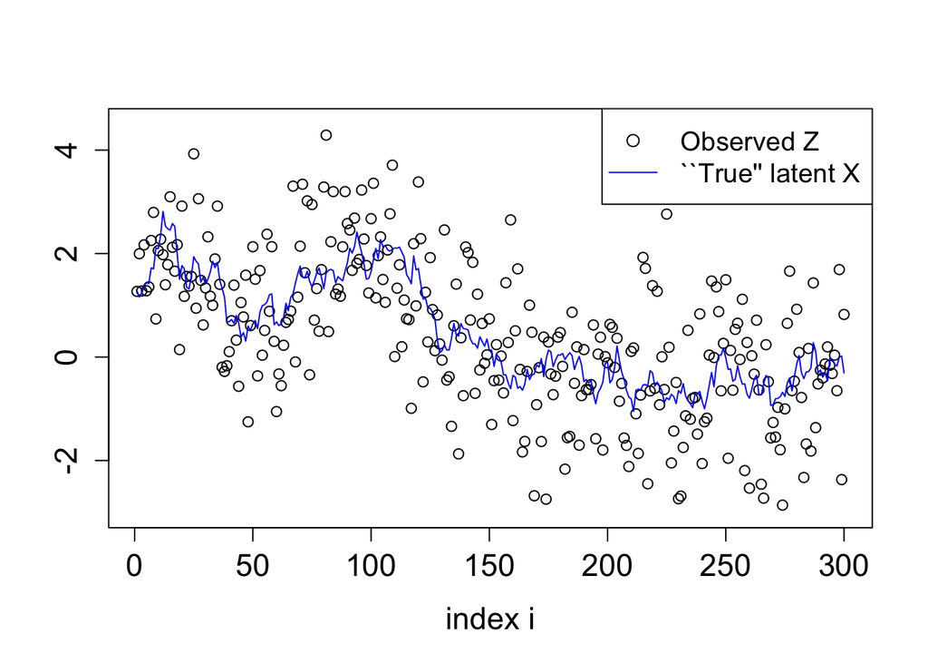

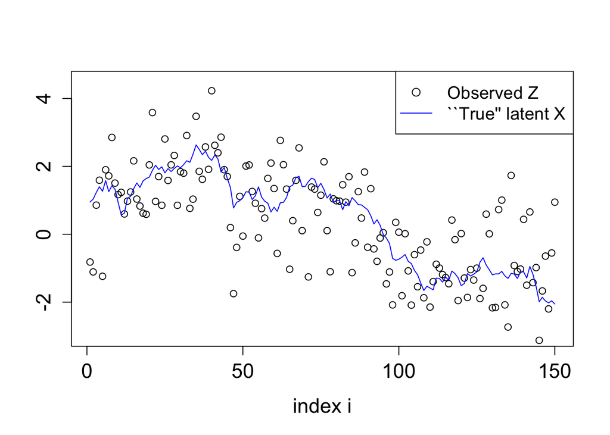

Graphical representation of two noisy Gaussian random walks of length $n=300$ and $n=150$ respectively. Each random walk was simulated with parameter $(\eta^*,\varepsilon^*) = (1.1,0.2)$ and $\alpha=1$.

```r
source("R_code/simulation.R")
sim = simu(n = c(300,150), eta = 1.1, epsilon = 0.2, alpha = 1, seed = 42)

j=1 # sequence number j
plot(sim$z[[j]], xlab = "index i", ylab = "", cex.lab = 1.4, cex.axis=1.4, ylim = c(-3,4.5))
lines(sim$x[[j]],col="blue");
legend("topright", legend = c("Observed Z", "``True'' latent X"), lty = c(NA,1), pch = c(1,NA), bg="white", col = c("black", "blue"), cex = 1.2)
#
j=2 # sequence number j
plot(sim$z[[j]], xlab = "index i", ylab = "", cex.lab = 1.4, cex.axis = 1.4, ylim = c(-3,4.5))
lines(sim$x[[j]],col="blue")
legend("topright", legend = c("Observed Z", "``True'' latent X"), lty = c(NA,1), pch = c(1,NA), bg="white", col = c("black", "blue"), cex = 1.2)
```

# First and second order derivatives of the log-likelihood

The main function of this document, *grw_der*, is contained in the file *compute_derivatives.R*. It takes an observed noisy random walk as input and returns the log-likelihood of the model, its gradient and its Hessian matrix at any point $(\eta, \varepsilon)$.

```r
rm(list=ls())
source("R_code/simulation.R")
source("R_code/compute_derivatives.R")

# simulations
alpha = 1 # fixed parameter
sim = simu(n = rep(100, 25), eta = 1.1, epsilon = 0.2, alpha = alpha, seed = 42)

data = sim$z
at = c(eta = 0.8, epsilon = 0.6)
h = 1e-6

# Compare exact and approximate values of the score
Exact = grw_der(param = at, data, Hess=FALSE)$score
Approximate = c((grw_der(param = at + c(h,0), data, Hess=FALSE)$loglik - grw_der(param = at, data, Hess=FALSE)$loglik) / h,
                (grw_der(param = at + c(0,h), data, Hess=FALSE)$loglik - grw_der(param = at, data, Hess=FALSE)$loglik) / h)
res = rbind(Exact, Approximate)
colnames(res) = c("$\\log \\eta$", "$\\log \\epsilon$")
knitr::kable(res, caption = "Exact and approximate score (by row, see header column) reported as parital derivative with respect to the parameter in columns (see header row).")
```

Exact and approximate score (by row, see header column) reported as parital derivative with respect to the parameter in columns (see header row).

|  | $\log \eta$ | $\log \epsilon$ |
| --- | --- | --- |
| Exact | -1262.755 | -845.0436 |
| Approximate | -1262.755 | -845.0440 |

```r
# Compare exact and approximate values of the Hessian matrix
Exact = grw_der(param = at, data, Hess=TRUE)$Hess[-2] # [-2] to remove the symmetric off diagonal component
Approximate = rbind(c((grw_der(param = at + c(h,0), data, Hess=FALSE)$score - grw_der(param = at, data, Hess=FALSE)$score)/h),
                    c((grw_der(param = at + c(0,h), data, Hess=FALSE)$score - grw_der(param = at, data, Hess=FALSE)$score)/h))[-2] # [-2] idem
res = rbind(Exact, Approximate)
colnames(res) = c("$(\\log \\eta, \\log \\eta)$", "$(\\log \\varepsilon, \\log \\eta)$", "$(\\log \\varepsilon, \\log \\varepsilon)$")
knitr::kable(-res, format = "simple", caption = "Exact and approximate observed FIM (by row, see header column) reported as parital derivative with respect to the parameter in columns (see header row).")
```

Exact and approximate observed FIM (by row, see header column) reported as parital derivative with respect to the parameter in columns (see header row).

|  | $(\log \eta, \log \eta)$ | $(\log \varepsilon, \log \eta)$ | $(\log \varepsilon, \log \varepsilon)$ |
| --- | --- | --- | --- |
| Exact | 1125.475 | -551.1198 | 761.1679 |
| Approximate | 1125.475 | -551.1199 | 761.1681 |

# Exemple of application: parameter estimation with the Newton-Raphson algorithm and standard deviation on parameters.

The score and observed FIM are useful in a variety of statistical inference. Among them, we propose to compute parameter estimates with the Newton-Rapshon (NR) algorithm and to compute confidence intervals on parameters.

The file *NR_algo.R* contains the function *optim_NR* for parameter estimation with the NR algorithm and *init_NR* for initializing *optim_NR*.

```r
rm(list=ls())
source("R_code/simulation.R")
source("R_code/compute_derivatives.R")
source("R_code/NR_algo.R")

#simulation
alpha = 1
sim = simu(n = rep(100, 25), eta = 1.1, epsilon = 0.2, alpha = alpha, seed = 42)
data = sim$z
# Estimation with the Newton-Raphson algorithm
init = init_NR(nrep = 10, data = data, verbose = FALSE)
opt = optim_NR(param = init, data = data, niter = 20, tol = 1e-15, verbose = TRUE)
```

```
## param= 0.2014617 -1.354124 loglik= -4042.882 tol= 0.2379223 maxScore= 74.65461
## param= 0.07857706 -1.592046 loglik= -4009.416 tol= 0.0156611 maxScore= 71.1541
## param= 0.09423816 -1.584686 loglik= -4008.833 tol= 0.0002706038 maxScore= 1.013108
## param= 0.09445903 -1.584416 loglik= -4008.833 tol= 5.123868e-08 maxScore= 0.0002313469
## param= 0.09445908 -1.584416 loglik= -4008.833 tol= 2.525757e-15 maxScore= 1.142964e-11
## param= 0.09445908 -1.584416 loglik= -4008.833 tol= 2.220446e-15 maxScore= 5.835332e-13
## param= 0.09445908 -1.584416 loglik= -4008.833 tol= 3.330669e-15 maxScore= 7.76712e-13
## param= 0.09445908 -1.584416 loglik= -4008.833 tol= 6.661338e-16 maxScore= 1.39444e-13
```

Intermediate quantities are displayed at each iteration of *optim_NR* if *verbose* is set at *TRUE*. Among them, *maxScore* denotes the highest absolute value of the exact score such that one can check if the score vanishes at last iteration. The score is also returned as an output for verification:

```r
# check that the score vanishes at last iteration
knitr::kable(opt$score, caption = "Verification : check score at parameter estimate")
```

Verification : check score at parameter estimate

| x |
| --- |
| 0 |
| 0 |

We propose below a table of parameter estimate along with 95% confidence interval where we assume that the covariance matrix of parameters is the inverse of the observed FIM. Note that the Hessian matrix returned by *optim_NR* is identical to the one return by *grw_der* at parameter estimate.

```r
opt$Hess
```

```
##            [,1]      [,2]
## [1,] -4305.5656 -227.8851
## [2,]  -227.8851 -238.6641
```

```r
grw_der(param = opt$param, data = data, Hess = TRUE)$Hess
```

```
##            [,1]      [,2]
## [1,] -4305.5656 -227.8851
## [2,]  -227.8851 -238.6641
```

```r
I = -solve(opt$Hess) # inverse of Fisher Info
res = rbind(exp(opt$param[1] + c(0,-1,1) * 1.96 * sqrt(diag(I))[1]),
            exp(opt$param[2] + c(0,-1,1) * 1.96 * sqrt(diag(I))[2]))
rownames(res) = c("$\\eta$", "$\\varepsilon$")
colnames(res) = c("estimate", "lower bound", "upper bound")

knitr::kable(res,
 format = "simple", caption = "Parameter estimates along with 95% confidence interval computed with the Newton-Raphson algorithm over a dataset composed of 25 sequences of length 100 each and simulated with true parameter $(\\eta^*,\\varepsilon^*) = (1.1, 0.2)$."
  )
```

Parameter estimates along with 95% confidence interval computed with the Newton-Raphson algorithm over a dataset composed of 25 sequences of length 100 each and simulated with true parameter $(\eta^*,\varepsilon^*) = (1.1, 0.2)$.

|  | estimate | lower bound | upper bound |
| --- | --- | --- | --- |
| $\eta$ | 1.0990642 | 1.0658835 | 1.1332778 |
| $\varepsilon$ | 0.2050676 | 0.1800322 | 0.2335844 |

# Additional output of *grw_der*: posterior state densities

Additionally, if *post_x* is set at *TRUE* as input, the function *grw_der* returns the vector of mean and variance of posterior states for a given parameter. A graphical representation of a noisy GRW with observed vector $z$ and ``true’’ latent random walk $X$ is drawn below along with the vector of mean estimates of the latent states and their 95% confidence interval computed with the vector of estimated variances.

```r
rm(list=ls())
source("R_code/simulation.R")
source("R_code/compute_derivatives.R")
source("R_code/NR_algo.R")

#simulation of a single sequence of length 300
alpha = 1
sim = simu(n = 300, eta = 1.1, epsilon = 0.2, alpha = alpha, seed = 42)
data = sim$z

# Estimation with NR
init = init_NR(nrep = 10, data = data, verbose = FALSE)
opt = optim_NR(param = init, data = data, niter = 20, tol = 1e-15, verbose = TRUE)
```

```
## param= -0.00123018 -1.266805 loglik= -476.2688 tol= 0.6076118 maxScore= 29.79407
## param= 0.09420998 -1.874417 loglik= -471.3723 tol= 0.0265987 maxScore= 0.724452
## param= 0.08450973 -1.901016 loglik= -471.3355 tol= 0.0001242403 maxScore= 0.06635341
## param= 0.08463397 -1.901034 loglik= -471.3355 tol= 1.604862e-08 maxScore= 7.192455e-06
## param= 0.08463399 -1.901034 loglik= -471.3355 tol= 8.881784e-16 maxScore= 1.68374e-13
```

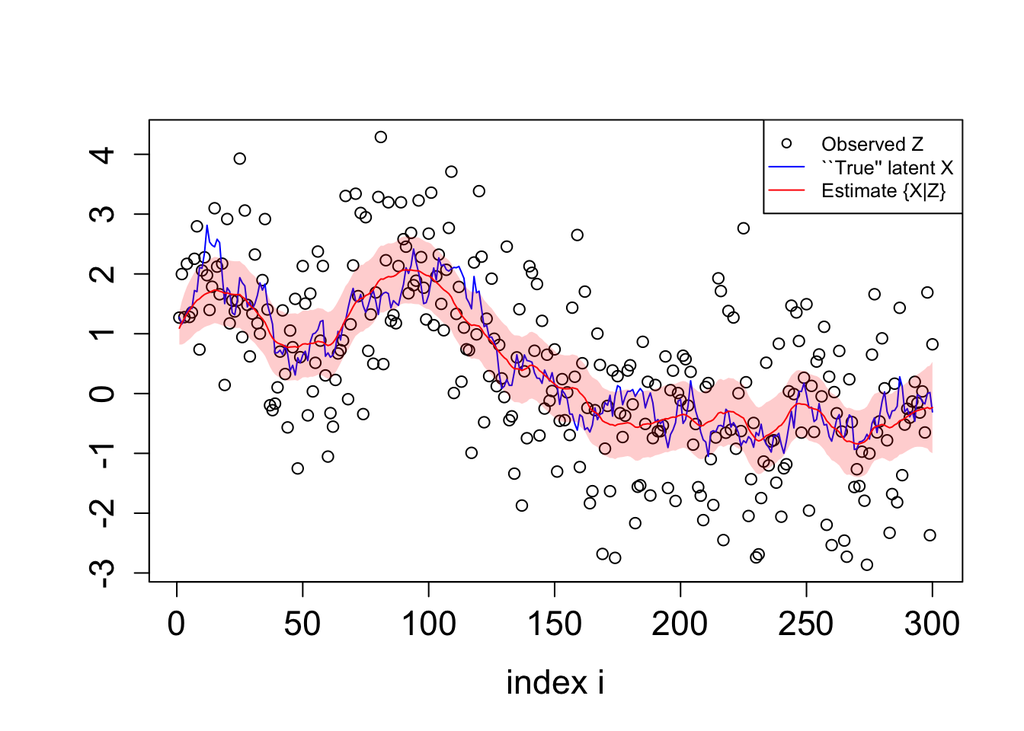

```r
# compute posterior distribution of x with estimated parameters
res = grw_der(opt$param, sim$z, Hess = FALSE, post.x = TRUE)
j=1 # sequence number j
par(mar = c(5.1, 5.1, 4.1, 2.1))
plot(sim$z[[j]], xlab = "index i", ylab = "", cex.lab = 1.4, cex.axis = 1.4) # observed sequence
lines(sim$x[[j]],col="blue"); # "true" latent random walk
lines(res$post.x$M[[j]], col="red") # mean estimates
polygon(c(1:length(sim$z[[j]]), length(sim$z[[j]]):1),
        c(res$post.x$M[[j]] - 1.96 * sqrt(res$post.x$S2[[j]]), # lower bound computed with variance estimates
          rev(res$post.x$M[[j]] + 1.96 * sqrt(res$post.x$S2[[j]]))), # upper bound computed with variance estimates
        col = rgb(1,0,0,alpha=0.20), border=FALSE)
legend("topright", legend = c("Observed Z", "``True'' latent X", "Estimate {X|Z}"), lty = c(NA,1,1), pch = c(1,NA,NA), bg="white", col = c("black", "blue", "red"), cex = 0.8)
```

# Contact

If you have any question, query, suggestion, etc., please contact Alexandra Lefebvre.

# References

[1] *Direct Calculation of the Information Matrix via the EM Algorithm* (David Oakes, 1999) 〈https://www.jstor.org/stable/2680653〉